# Anemia e fatores associados em adultos indígenas Xavante

Welington Nogueira

## 🔹 Introdução

Este estudo tem como objetivo analisar a ocorrência de anemia e seus fatores associados em adultos indígenas da etnia Xavante. Trata-se de uma análise epidemiológica observacional, com foco em determinantes sociodemográficos, nutricionais e de acesso alimentar.

## Leitura dos Dados

```r
dados <- read.csv2("Banco2011_Raquel_15.03.22.csv")
```

## Criação de variáveis

```r
dados <- dados %>%
mutate(
filhos = case_when(
filho.n.vivo.tot > 0  & filho.n.vivo.tot < 4  ~ "1",
filho.n.vivo.tot >= 4 & filho.n.vivo.tot < 8  ~ "2",
filho.n.vivo.tot >= 8 & filho.n.vivo.tot < 16 ~ "3",
TRUE ~ "4"
)
) %>%
filter(!(filhos == "4" & sexo == "1")) %>%
mutate(filhos = ifelse(filhos == "4", NA, filhos))
```

## Seleção de variáveis e Limpeza

```r
df <- dados %>%
select(
anemia        = Anemia,
sexo,
filhos,
imc           = IMCcat,
renda         = rendapercapcat,
faixa_etaria  = Fetaria,
escolaridade,
socio_index   = socioindexcat,
cultivo       = cultivocat,
coleta        = coletacat,
compra        = compracat
) %>%
filter(
anemia != "#NULO!",
imc != "#NULO!",
escolaridade != "#NULO!",
socio_index != "#NULO!",
cultivo != "#NULO!",
coleta != "#NULO!",
compra != "#NULO!"
) %>%
mutate(across(everything(), ~ str_replace(.x, ",00", "")))
```

## Padronização e Limpeza de Dados

```r
df <- df %>%
mutate(
anemia = factor(anemia, c("0","1"), c("Não","Sim")),
sexo   = factor(sexo, c("0","1"), c("Homem","Mulher")),
filhos = factor(filhos, c("1","2","3"), c("1–3","4–7",">8")),
imc    = factor(imc, c("1","2","3","4"),
c("Baixo peso","Adequado","Sobrepeso","Obesidade")),
renda  = factor(renda, c("1","2","3"), c("0–54","55–109","110–550")),
faixa_etaria = factor(faixa_etaria, c("1","2","3"), c("15–19","20–49","50+")),
escolaridade = factor(escolaridade, c("0","1","2","3"),
c("1–4 séries","5–8 séries","Ens Médio","Sem escolaridade")),
socio_index = factor(socio_index, c("1","2","3"), c("Baixo","Médio","Alto")),
cultivo = factor(cultivo, c("1","2","3"), c("Baixo","Médio","Alto")),
coleta  = factor(coleta,  c("1","2","3"), c("Baixo","Médio","Alto")),
compra  = factor(compra,  c("1","2","3"), c("Baixo","Médio","Alto"))
)
```

## 🔹 Análise Exploratória dos Dados

A amostra analisada foi composta por 417 indivíduos adultos indígenas Xavante. Observou-se uma prevalência de anemia de 56,8%, indicando elevada carga do agravo na população estudada.

Esses resultados sugerem uma população relativamente homogênea do ponto de vista socioeconômico, o que pode influenciar as análises inferenciais subsequentes.

```r
tabela_freq <- df %>%
  pivot_longer(
    cols = everything(),
    names_to = "Variavel",
    values_to = "Categoria"
  ) %>%
  filter(!is.na(Categoria)) %>%
  count(Variavel, Categoria, name = "Frequencia") %>%
  group_by(Variavel) %>%
  mutate(
    Percentual = round(100 * Frequencia / sum(Frequencia), 1)
  ) %>%
  ungroup()

knitr::kable(
  tabela_freq,
  caption = "Distribuição das variáveis — frequência absoluta e relativa (%)"
)
```

Distribuição das variáveis — frequência absoluta e relativa (%)

| Variavel | Categoria | Frequencia | Percentual |
| --- | --- | --- | --- |
| anemia | Não | 180 | 43.2 |
| anemia | Sim | 237 | 56.8 |
| coleta | Baixo | 143 | 34.3 |
| coleta | Médio | 126 | 30.2 |
| coleta | Alto | 148 | 35.5 |
| compra | Baixo | 145 | 34.8 |
| compra | Médio | 139 | 33.3 |
| compra | Alto | 133 | 31.9 |
| cultivo | Baixo | 142 | 34.1 |
| cultivo | Médio | 148 | 35.5 |
| cultivo | Alto | 127 | 30.5 |
| escolaridade | 1–4 séries | 119 | 28.5 |
| escolaridade | 5–8 séries | 101 | 24.2 |
| escolaridade | Ens Médio | 155 | 37.2 |
| escolaridade | Sem escolaridade | 42 | 10.1 |
| faixa_etaria | 15–19 | 101 | 24.2 |
| faixa_etaria | 20–49 | 253 | 60.7 |
| faixa_etaria | 50+ | 63 | 15.1 |
| filhos | 1–3 | 70 | 36.3 |
| filhos | 4–7 | 70 | 36.3 |
| filhos | >8 | 53 | 27.5 |
| imc | Baixo peso | 2 | 0.5 |
| imc | Adequado | 154 | 36.9 |
| imc | Sobrepeso | 177 | 42.4 |
| imc | Obesidade | 84 | 20.1 |
| renda | 0–54 | 125 | 30.0 |
| renda | 55–109 | 202 | 48.4 |
| renda | 110–550 | 90 | 21.6 |
| sexo | Homem | 224 | 53.7 |
| sexo | Mulher | 193 | 46.3 |
| socio_index | Baixo | 149 | 35.7 |
| socio_index | Médio | 126 | 30.2 |
| socio_index | Alto | 142 | 34.1 |

## 🔹 Distribuição da anemia

Os gráficos de proporção evidenciaram diferenças visuais relevantes na prevalência de anemia segundo sexo e IMC:

- A proporção de anemia foi visualmente maior entre mulheres;
- Observou-se tendência de menor prevalência de anemia em indivíduos com IMC mais elevado, particularmente entre obesos.

Esses padrões motivaram a realização dos testes de associação formal.

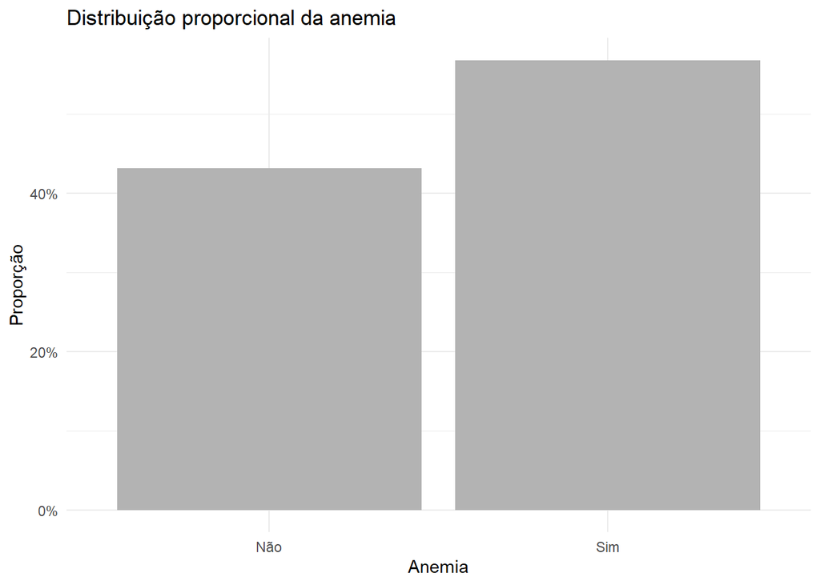

```r
ggplot(df, aes(x = anemia)) +
  geom_bar(
    aes(y = after_stat(count / sum(count))),
    fill = "grey70"
  ) +
  scale_y_continuous(labels = scales::percent) +
  labs(
    x = "Anemia",
    y = "Proporção",
    title = "Distribuição proporcional da anemia"
  ) +
  theme_minimal()
```

# Proporção de anemia segundo sexo

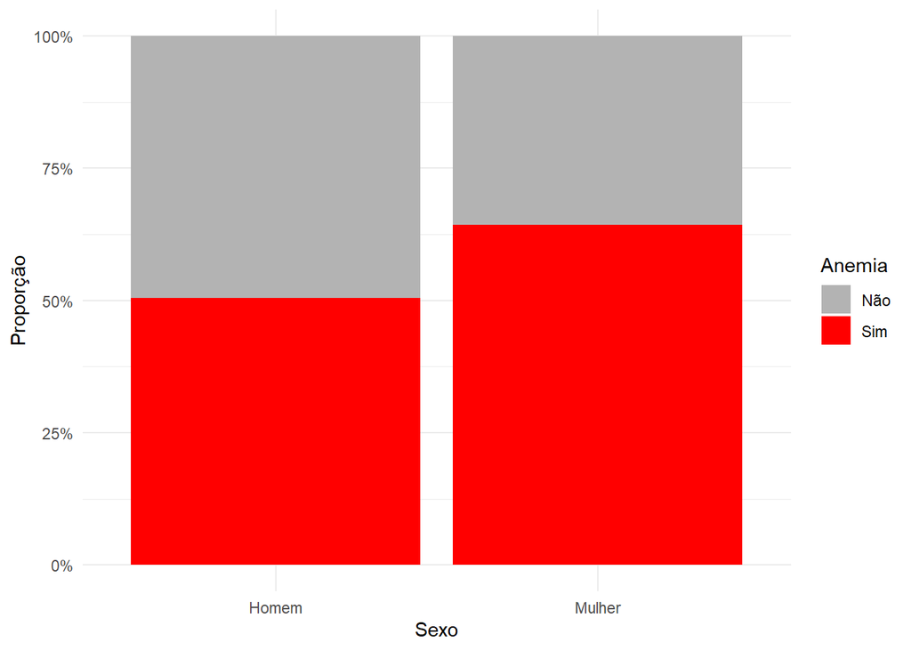

```r
ggplot(df, aes(sexo, fill = anemia)) +
geom_bar(position = "fill") +
scale_y_continuous(labels = percent) +
scale_fill_manual(values = c("Não" = "grey70", "Sim" = "red")) +
labs(x = "Sexo", y = "Proporção", fill = "Anemia") +
theme_minimal()
```

# Proporção de anemia segundo IMC

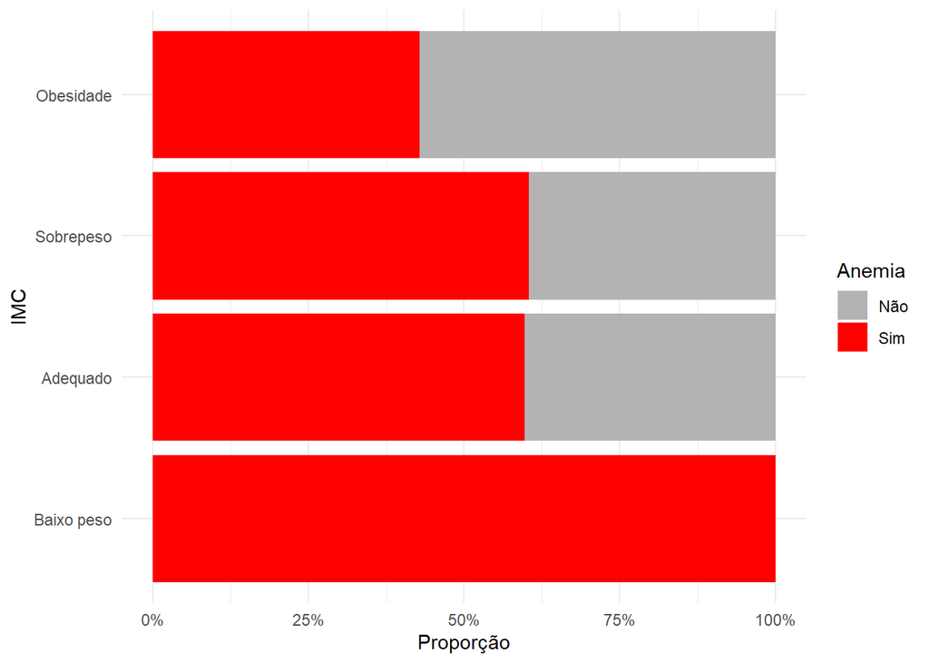

```r
ggplot(df, aes(imc, fill = anemia)) +
geom_bar(position = "fill") +
coord_flip() +
scale_y_continuous(labels = percent) +
scale_fill_manual(values = c("Não" = "grey70", "Sim" = "red")) +
labs(x = "IMC", y = "Proporção", fill = "Anemia") +
theme_minimal()
```

## Heatmap Epidemiológico

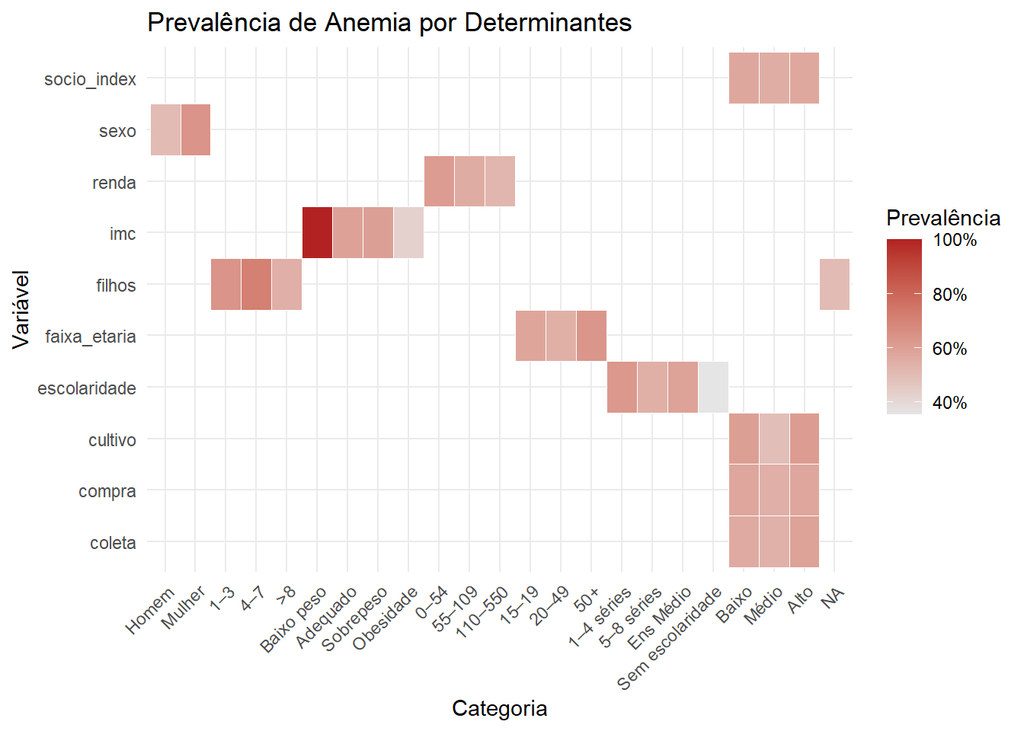

```r
heat_data <- df %>%
pivot_longer(-anemia, names_to = "variavel", values_to = "categoria") %>%
group_by(variavel, categoria) %>%
summarise(prevalencia = mean(anemia == "Sim"), .groups = "drop")

ggplot(heat_data,
aes(categoria, variavel, fill = prevalencia)) +
geom_tile(color = "white") +
scale_fill_gradient(low = "grey90", high = "firebrick", labels = percent) +
labs(title = "Prevalência de Anemia por Determinantes",
x = "Categoria", y = "Variável", fill = "Prevalência") +
theme_minimal() +
theme(axis.text.x = element_text(angle = 45, hjust = 1))
```

## 🔹 Testes de associação (Qui-quadrado)

Foram realizados testes do Qui-quadrado de independência entre a anemia e cada variável explicativa.

**Sexo**

Foi observada associação estatisticamente significativa entre sexo e anemia (p < 0,01). Mulheres apresentaram maior proporção de anemia em comparação aos homens.

**Filhos**

Não foi identificada associação estatisticamente significativa entre o número de filhos e a ocorrência de anemia (p = 0,16).

**IMC**

O IMC apresentou associação significativa com anemia (p = 0,021), sugerindo que o estado nutricional está relacionado ao desfecho.

**Renda**

Não houve associação estatisticamente significativa entre renda per capita e anemia (p = 0,37).

**Faixa Etária**

A faixa etária não apresentou associação significativa com anemia (p = 0,41).

**Escolaridade**

**Índice Socioeconômico**

Não houve associação significativa entre o índice socioeconômico e anemia (p = 0,93).

**Cultivo**

A variável cultivo apresentou associação limítrofe (p ≈ 0,07), indicando possível tendência, porém sem significância estatística ao nível convencional.

**Coleta e Compra**

Não foram observadas associações estatisticamente significativas entre coleta ou compra de alimentos e anemia.

## 🔹 Tamanho do Efeito (V de Cramer)

Os valores do V de Cramer indicaram que, mesmo quando estatisticamente significativas, as associações foram fracas:

- Sexo: V ≈ 0,14 (efeito fraco);
- IMC: V ≈ 0,15 (efeito fraco);
- Escolaridade: V ≈ 0,16 (efeito fraco).

Para as demais variáveis, os valores foram muito baixos, reforçando a ausência de associação relevante.

Esses resultados indicam que, embora existam associações estatísticas, o impacto isolado de cada variável é limitado.

```r
vars <- names(df)[-1]

qui <- lapply(vars, function(v){
ct <- table(df[[v]], df$anemia)
data.frame(
Variavel = v,
Qui2 = chisq.test(ct)$statistic,
p_valor = chisq.test(ct)$p.value
)
})

bind_rows(qui) %>%
kable() %>%
kable_styling()
```

|  | Variavel | Qui2 | p_valor |
| --- | --- | --- | --- |
| X-squared…1 | sexo | 7.4977097 | 0.0061778 |
| X-squared…2 | filhos | 3.6673804 | 0.1598227 |
| X-squared…3 | imc | 9.6824480 | 0.0214676 |
| X-squared…4 | renda | 2.0033268 | 0.3672680 |
| X-squared…5 | faixa_etaria | 1.7815164 | 0.4103445 |
| X-squared…6 | escolaridade | 10.1298917 | 0.0174937 |
| X-squared…7 | socio_index | 0.1339280 | 0.9352289 |
| X-squared…8 | cultivo | 5.2946628 | 0.0708400 |
| X-squared…9 | coleta | 0.8397468 | 0.6571300 |
| X-squared…10 | compra | 0.3959233 | 0.8204013 |

```r
cramer <- lapply(vars, function(v){
data.frame(
Variavel = v,
CramerV = rcompanion::cramerV(df[[v]], df$anemia)
)
})

bind_rows(cramer) %>%
kable() %>%
kable_styling()
```

|  | Variavel | CramerV |
| --- | --- | --- |
| Cramer V…1 | sexo | 0.13890 |
| Cramer V…2 | filhos | 0.09378 |
| Cramer V…3 | imc | 0.15240 |
| Cramer V…4 | renda | 0.06931 |
| Cramer V…5 | faixa_etaria | 0.06536 |
| Cramer V…6 | escolaridade | 0.15590 |
| Cramer V…7 | socio_index | 0.01792 |
| Cramer V…8 | cultivo | 0.11270 |
| Cramer V…9 | coleta | 0.04488 |
| Cramer V…10 | compra | 0.03081 |

## 🔹 Imputação de valores na variável filhos

A variável número de filhos apresentou valores ausentes relevantes. Optou-se pela imputação pela moda, por se tratar de uma variável categórica ordinal e por preservar a estrutura original dos dados.

```r
na_antes <- sum(is.na(df$filhos))

tab_na_antes <- data.frame(
  Variavel = "filhos",
  NAs = na_antes
)

knitr::kable(
  tab_na_antes,
  caption = "Valores ausentes na variável filhos (antes da imputação)"
)
```

Valores ausentes na variável filhos (antes da imputação)

| Variavel | NAs |
| --- | --- |
| filhos | 224 |

```r
moda <- function(x){
ux <- na.omit(x)
ux[which.max(tabulate(match(ux, ux)))]
}

df_imp <- df
df_imp$filhos[is.na(df_imp$filhos)] <- moda(df_imp$filhos)

na_depois <- sum(is.na(df_imp$filhos))

tab_na_depois <- data.frame(
  Variavel = "filhos",
  NAs = na_depois
)

knitr::kable(
  tab_na_depois,
  caption = "Valores ausentes na variável filhos (após imputação)"
)
```

Valores ausentes na variável filhos (após imputação)

| Variavel | NAs |
| --- | --- |
| filhos | 0 |

## 🔹 Regressão logística – Modelo completo

Foi ajustado um modelo de regressão logística incluindo todas as variáveis estudadas.

Principais Resultados:

- Sexo feminino mostrou-se fator associado à anemia (OR = 2,03; IC95%: 1,16–3,62);
- IMC apresentou associação inversa com anemia (OR = 0,72; IC95%: 0,55–0,95), sugerindo menor chance de anemia com aumento do IMC;

As demais variáveis não apresentaram associação estatisticamente significativa no modelo ajustado.

Desempenho do Modelo:

- AIC = 574,2
- Pseudo-R² de McFadden ≈ 3,2%

O baixo valor do pseudo-R² indica baixo poder explicativo, o que é comum em modelos epidemiológicos baseados em determinantes sociais isolados.

```r
df_model <- df_imp %>%
mutate(
anemia = ifelse(anemia == "Sim", 1, 0),
sexo   = ifelse(sexo == "Mulher", 1, 0),
filhos = as.numeric(factor(filhos)),
imc = as.numeric(factor(imc)),
renda = as.numeric(factor(renda)),
faixa_etaria = as.numeric(factor(faixa_etaria)),
escolaridade = as.numeric(factor(escolaridade)),
socio_index = as.numeric(factor(socio_index)),
cultivo = as.numeric(factor(cultivo)),
coleta = as.numeric(factor(coleta)),
compra = as.numeric(factor(compra))
)

modelo_logit <- glm(
anemia ~ sexo + filhos + imc + renda + faixa_etaria +
escolaridade + socio_index + cultivo + coleta + compra,
family = binomial, data = df_model
)
```

# 🔹 Resultados do modelo completo

```r
tidy(modelo_logit) %>%
kable() %>%
kable_styling()
```

| term | estimate | std.error | statistic | p.value |
| --- | --- | --- | --- | --- |
| (Intercept) | 1.5019826 | 0.8692796 | 1.7278476 | 0.0840155 |
| sexo | 0.7095848 | 0.2893772 | 2.4521101 | 0.0142021 |
| filhos | -0.2483939 | 0.2116185 | -1.1737816 | 0.2404825 |
| imc | -0.3263730 | 0.1414970 | -2.3065716 | 0.0210787 |
| renda | -0.1785418 | 0.1440782 | -1.2392004 | 0.2152713 |
| faixa_etaria | 0.1471600 | 0.2048291 | 0.7184525 | 0.4724784 |
| escolaridade | -0.0994450 | 0.1355158 | -0.7338262 | 0.4630547 |
| socio_index | 0.0245127 | 0.1245817 | 0.1967600 | 0.8440153 |
| cultivo | -0.0341627 | 0.1338120 | -0.2553037 | 0.7984885 |
| coleta | 0.0251737 | 0.1237346 | 0.2034491 | 0.8387840 |
| compra | -0.0060212 | 0.1291897 | -0.0466072 | 0.9628263 |

```r
data.frame(
AIC = AIC(modelo_logit),
Pseudo_R2 = 1 - modelo_logit$deviance / modelo_logit$null.deviance
) %>%
kable()
```

| AIC | Pseudo_R2 |
| --- | --- |
| 574.1988 | 0.0316871 |

## 🔹 Regressão logística – Modelo reduzido (sexo + IMC)

Considerando os resultados anteriores, foi ajustado um modelo reduzido contendo apenas sexo e IMC.

Resultados:

- Sexo feminino manteve associação significativa com anemia (OR = 1,80; IC95%: 1,12–2,91);
- IMC manteve associação limítrofe, indicando tendência protetora.

```r
set.seed(123)
idx <- createDataPartition(df_model$anemia, p = 0.7, list = FALSE)

treino <- df_model[idx, ]
teste  <- df_model[-idx, ]

modelo_red <- glm(anemia ~ sexo + imc,
family = binomial,
data = treino)

tidy(modelo_red, exponentiate = TRUE, conf.int = TRUE) %>%
kable() %>%
kable_styling()
```

| term | estimate | std.error | statistic | p.value | conf.low | conf.high |
| --- | --- | --- | --- | --- | --- | --- |
| (Intercept) | 2.3298369 | 0.4717267 | 1.792984 | 0.0729755 | 0.9286073 | 5.925396 |
| sexo | 1.7982517 | 0.2430833 | 2.414049 | 0.0157763 | 1.1200925 | 2.908473 |
| imc | 0.7557862 | 0.1613785 | -1.735031 | 0.0827353 | 0.5492388 | 1.035474 |

# 🔹 Matriz de Confusão

```r
teste$prob <- predict(modelo_red, teste, type = "response")
teste$pred <- ifelse(teste$prob >= 0.5, 1, 0)

cm <- confusionMatrix(
factor(teste$pred),
factor(teste$anemia),
positive = "1"
)

kable(as.data.frame(cm$table))
```

| Prediction | Reference | Freq |
| --- | --- | --- |
| 0 | 0 | 13 |
| 1 | 0 | 45 |
| 0 | 1 | 6 |
| 1 | 1 | 61 |

# 🔹 Resultados Modelo reduzido

Esses resultados reforçam que o modelo não é adequado como classificador clínico, mas cumpre seu papel analítico.

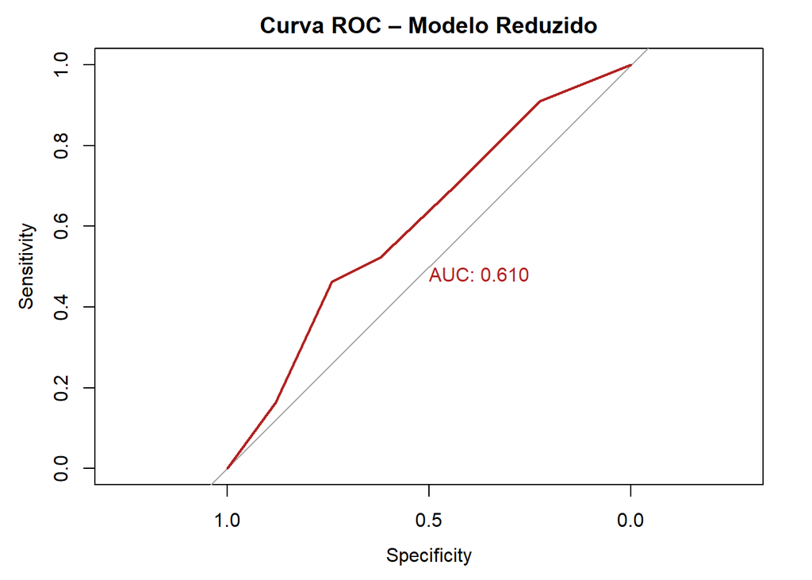

```r
roc_teste <- roc(teste$anemia, teste$prob)

plot(roc_teste,
col = "firebrick",
print.auc = TRUE,
main = "Curva ROC – Modelo Reduzido")
```

```r
data.frame(
AIC = AIC(modelo_red),
Pseudo_R2 = 1 - modelo_red$deviance / modelo_red$null.deviance
) %>%
kable()
```

| AIC | Pseudo_R2 |
| --- | --- |
| 394.3458 | 0.0214825 |

# 🔹 Conclusão

Os resultados indicam que a anemia apresenta alta prevalência entre adultos indígenas Xavante. O sexo feminino mostrou-se um fator associado consistente, enquanto o IMC apresentou tendência protetora.

**1)** homogeneidade socioeconômica da população Xavante;

**2)** influência de fatores não observados, como parasitoses, inflamação crônica, padrões alimentares específicos ou aspectos culturais.